# post3

Rongyun Tang

December 11, 2018

## Daily Demand Forecasting Orders Data

research outlines:

1. Objective:task is to determine what kind of order resources contribute most to the information, and then to reduce data dimentions.
2. Method: CPA
3. Data Source:this “Daily Demand Forecasting Orders Data(DDFOD)” dataset was downloaded from UCI Machine Learning website: https://archive.ics.uci.edu/ml/datasets/Daily+Demand+Forecasting+Orders. The dataset was collected during 60 days, this is a real database of a brazilian logistics company.Twelve predictive attributes and a target that is the total of orders for daily treatment.

=======================================================================================================

Attribute Information:

=======================================================================================================

he dataset was collected during 60 days, this is a real database of a brazilian logistics company. The dataset has twelve predictive attributes and a target that is the total of orders for daily treatment. The database was used in academic research at the Universidade Nove de Julho. .arff header for Weka:

Week_of_the_month (WM): {1.0, 2.0, 3.0, 4.0, 5.0} Day_of_the_week_(Monday_to_Friday)(DW): {2.0, 3.0, 4.0, 5.0, 6.0} Non_urgent_order(NUO): integer Urgent order(UO): integer Order type A(typeA): integer Order type B(typeB): integer Order type C(typeC):integer Fiscal sector orders(FO): integer Orders from the traffic controller sector(Traffic): integer Banking orders (1)(Bank1): integer Banking orders (2)(Bank2): integer Banking orders (3)(Bank3): integer Target(Total_orders)(Total):integer

## 1. Data Preprocessing

```r
# Rename column names and Read data
rawdata <- read.csv('Daily_Demand_Forecasting_Orders2.csv')
head(rawdata)
```

```
##   WM DW     NUO      UO  typeA   typeB   typeC     FO Traffic Bank1  Bank2
## 1  1  4 316.307 223.270 61.543 175.586 302.448  0.000   65556 44914 188411
## 2  1  5 128.633  96.042 38.058  56.037 130.580  0.000   40419 21399  89461
## 3  1  6  43.651  84.375 21.826  25.125  82.461  1.386   11992  3452  21305
## 4  2  2 171.297 127.667 41.542 113.294 162.284 18.156   49971 33703  69054
## 5  2  3  90.532 113.526 37.679  56.618 116.220  6.459   48534 19646  16411
## 6  2  4 110.925  96.360 30.792  50.704 125.868 79.000   52042  8773  47522
##   Bank3   Total
## 1 14793 539.577
## 2  7679 224.675
## 3 14947 129.412
## 4 18423 317.120
## 5 20257 210.517
## 6 24966 207.364
```

```r
DOY<-as.factor(rawdata$WM*30+rawdata$DW)    # transfer week of month and day of week into day of year(DOY)
data2<-cbind(DOY,rawdata[,3:13])
head(data2)
```

```
##   DOY     NUO      UO  typeA   typeB   typeC     FO Traffic Bank1  Bank2
## 1  34 316.307 223.270 61.543 175.586 302.448  0.000   65556 44914 188411
## 2  35 128.633  96.042 38.058  56.037 130.580  0.000   40419 21399  89461
## 3  36  43.651  84.375 21.826  25.125  82.461  1.386   11992  3452  21305
## 4  62 171.297 127.667 41.542 113.294 162.284 18.156   49971 33703  69054
## 5  63  90.532 113.526 37.679  56.618 116.220  6.459   48534 19646  16411
## 6  64 110.925  96.360 30.792  50.704 125.868 79.000   52042  8773  47522
##   Bank3   Total
## 1 14793 539.577
## 2  7679 224.675
## 3 14947 129.412
## 4 18423 317.120
## 5 20257 210.517
## 6 24966 207.364
```

## 2.Data Exploration

```r
# Missing value detection
sum(is.na(data2))
```

```
## [1] 0
```

```r
print("Numbers of missing values : 0")
```

```
## [1] "Numbers of missing values : 0"
```

```r
# Data Correlationships

#install.packages("ggcorrplot")
library('ggcorrplot')
corr <- round(cor(data2[,c(-1,-12)]), 1)
head(corr[, 1:6])
```

```
##        NUO  UO typeA typeB typeC   FO
## NUO    1.0 0.6   0.6   0.8   0.8 -0.1
## UO     0.6 1.0   0.4   0.5   0.8  0.0
## typeA  0.6 0.4   1.0   0.4   0.2  0.1
## typeB  0.8 0.5   0.4   1.0   0.5 -0.1
## typeC  0.8 0.8   0.2   0.5   1.0  0.0
## FO    -0.1 0.0   0.1  -0.1   0.0  1.0
```

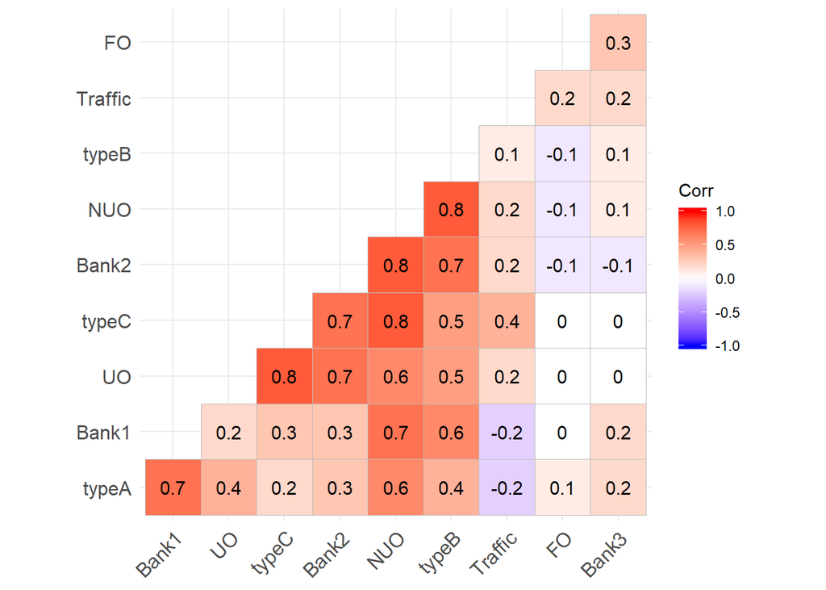

```r
ggcorrplot(corr, hc.order = TRUE, type = "lower",lab = TRUE)
```

```r
# Resutls show that there are many variables mutually correlated, dimension could be reduced with PCA method.
```

## 3. PCA and Visualization

```r
# 3.1 apply PCA

library(factoextra)
data.pca <- prcomp(data2[,c(-1,-12)], center = TRUE,scale. = TRUE)
summary(data.pca)
```

```
## Importance of components:
##                           PC1    PC2    PC3    PC4     PC5     PC6     PC7
## Standard deviation     2.1073 1.2802 1.2172 0.8666 0.77855 0.64800 0.59744
## Proportion of Variance 0.4441 0.1639 0.1482 0.0751 0.06061 0.04199 0.03569
## Cumulative Proportion  0.4441 0.6080 0.7561 0.8312 0.89183 0.93382 0.96951
##                            PC8     PC9    PC10
## Standard deviation     0.47140 0.26567 0.10986
## Proportion of Variance 0.02222 0.00706 0.00121
## Cumulative Proportion  0.99173 0.99879 1.00000
```

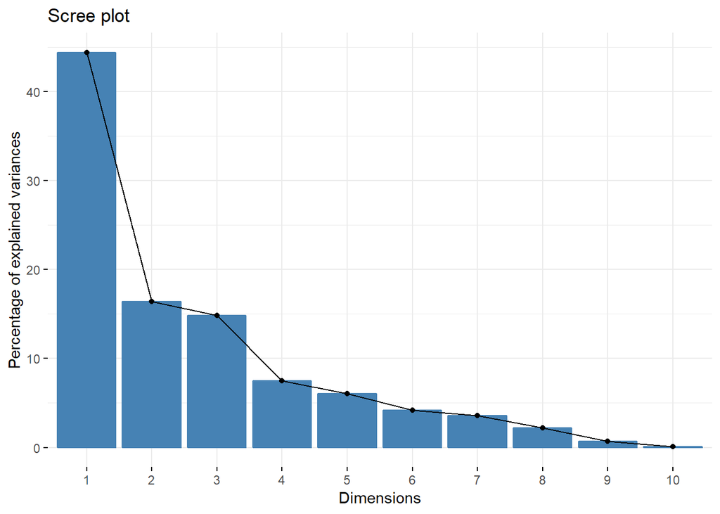

```r
# 3.12 results: PC1 explains 44% of the total variance,  PC2 explains 16% of the variance , PC3 expalins 15% of the total variance

fviz_eig(data.pca)
```

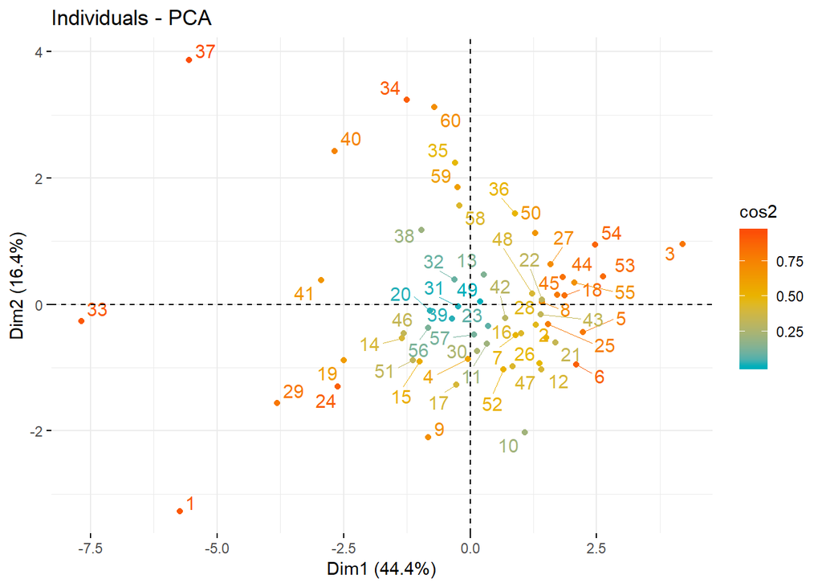

```r
#3.2 Individuals with a similar profile are grouped together
fviz_pca_ind(data.pca,
             col.ind = "cos2", # Color by the quality of representation
             gradient.cols = c("#00AFBB", "#E7B800", "#FC4E07"),
             repel = TRUE     # Avoid text overlapping
             )
```